# Steps and Tasks

#### i. Pair plot that includes all the columns of the data frame

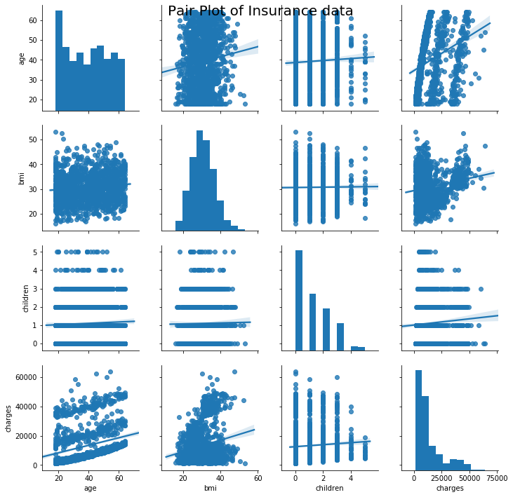

```python
sns.pairplot(insur_data, kind = "reg")
plt.suptitle('Pair Plot of Insurance data',
             size = 20);# plots scatter plots for every pair of attributes and histograms along the diagonal
plt.show()
```

- Age has positive correlation trend with charges.
- bmi has a similar positive trend with respect to charges.

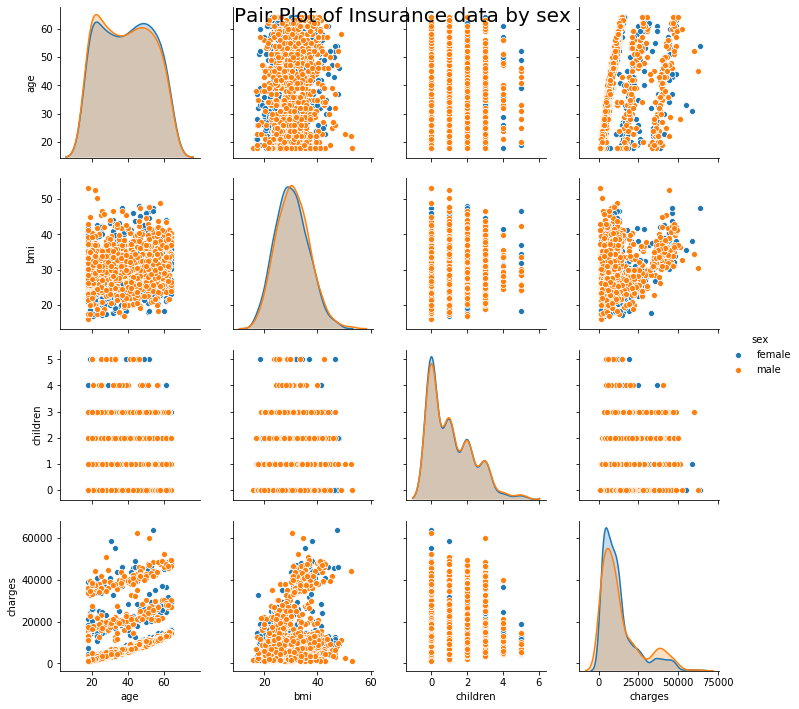

```python
sns.pairplot(insur_data, hue = "sex")
plt.suptitle('Pair Plot of Insurance data by sex',
             size = 20);# plots scatter plots for every pair of attributes and histograms along the diagonal
plt.show()
```

- Age has positive correlation trend with charges wherein there are intensively shown by Male and bit dispersed for females.
- bmi has a similar positive trend with respect to charges by sex.

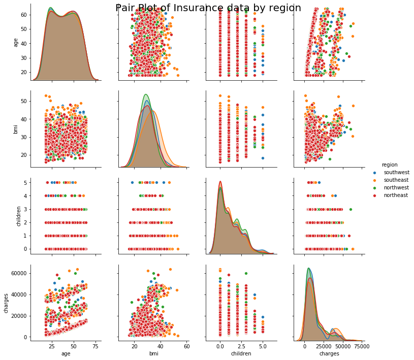

```python
sns.pairplot(insur_data, hue = "region")
plt.suptitle('Pair Plot of Insurance data by region',
             size = 20);# plots scatter plots for every pair of attributes and histograms along the diagonal
plt.show()
```

- Age has positive correlation trend with charges wherein northeast has bit more linear trend when compared to other regions.
- bmi has a dispersed trend with respect to charges by region.

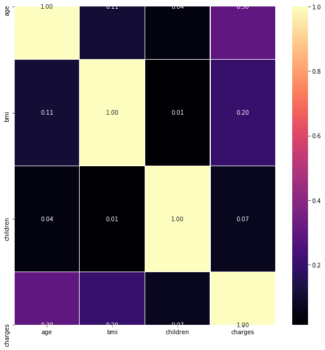

```python
# Heat map for checking the correlation
fig,ax = plt.subplots(figsize=(10, 10))
sns.heatmap(insur_data.corr(), ax=ax, annot=True, linewidths=0.05, fmt= '.2f',cmap="magma") # the color intensity is based on
plt.show()
```

- Similar positive correlation for bmi and age with respect to charges, the rest of the attributes do not show much correlation

### Answer the following questions with statistical evidence

#### a. Do charges of people who smoke differ significantly from the people who don't?

```python
# array of values for Charges & smoker
smoke_charge = np.array(insur_data[['charges','smoker']])
```

```python
# Data split for group 1 (smokers) & group 2 (non smokers)
group1 = smoke_charge[:, 1] == "no"
group1 = smoke_charge[group1][:, 0]
group2 = smoke_charge[:, 1] == "yes"
group2 = smoke_charge[group2][:, 0]
```

```python
# load the necessary libraries
from scipy.stats import ttest_1samp, ttest_ind, mannwhitneyu, levene, shapiro
from statsmodels.stats.power import ttest_power
```

```python
# two-sample t-test
# null hypothesis: the two groups have the same mean
# this test assumes the two groups have the same variance...

t_statistic, p_value = ttest_ind(group1, group2)
print(t_statistic, p_value)
```

```
-46.664921172723744 8.271435842174398e-283
```

```python
# p_value < 0.05 => alternative hypothesis:
# they don't have the same mean at the 5% significance level
print ("two-sample t-test p-value=", p_value)
```

```
two-sample t-test p-value= 8.271435842174398e-283
```

- Yes charges of people who smoke differ significantly from the people who do not smoke

#### b. Does bmi of males differ significantly from that of females?

```python
# array of values for bmi and sex from insur_data
bmi_sex = np.array(insur_data[['bmi','sex']])
```

```python
# data split between group1 ( bmi for male) and group2 (bmi for female)
group1 = bmi_sex[:, 1] == "male"
group1 = bmi_sex[group1][:, 0]
group2 = bmi_sex[:, 1] == "female"
group2 = bmi_sex[group2][:, 0]
```

```python
# two-sample t-test
# null hypothesis: the two groups have the same mean
# this test assumes the two groups have the same variance...
t_statistic, p_value = ttest_ind(group1, group2)
print(t_statistic, p_value)
```

```
1.6967526357520633 0.08997637178987965
```

```python
# p_value > 0.05 => null hypothesis:
# they have the same mean at the 5% significance level
print ("two-sample t-test p-value=", p_value)
```

```
two-sample t-test p-value= 0.08997637178987965
```

- No, as the p-value is greater than 0.05 they have same mean at 5% significance level and bmi of males do not differ from that of females

#### c. Is the proportion of smokers significantly different in different genders?

- 'sex' and 'smoker' are two categorical variables
- We want to check if the proportion of smokers in the female population is significantly less than it is in the male population

#### Ho = The proportions are equal

#### Ha = The two proportions are not equal

```python
 # number of female smokers
female_smokers = insur_data[insur_data['sex'] == 'female'].smoker.value_counts()[1]
# number of male smokers
male_smokers = insur_data[insur_data['sex'] == 'male'].smoker.value_counts()[1]
# number of females in the data
n_females = insur_data.sex.value_counts()[1]
#number of males in the data
n_males = insur_data.sex.value_counts()[0]
```

```python
print([female_smokers, male_smokers] , [n_females, n_males])
print(f' Proportion of smokers in females, males = {round(115/662,2)}%, {round(159/676,2)}% respectively')
```

```
[115, 159] [662, 676]
 Proportion of smokers in females, males = 0.17%, 0.24% respectively
```

```python
from statsmodels.stats.proportion import proportions_ztest

stat, pval = proportions_ztest([female_smokers, male_smokers] , [n_females, n_males])

if pval < 0.05:
    print(f'With a p-value of {round(pval,4)} the difference is significant. Hence, We reject the null|')
else:
    print(f'With a p-value of {round(pval,4)} the difference is not significant. Hence, We fail to reject the null|')
```

```
With a p-value of 0.0053 the difference is significant. Hence, We reject the null|
```

#### d. Is the distribution of bmi across women with no children, one child and two children, the same?

```python
insur_data.head()
```

|  | age | sex | bmi | children | smoker | region | charges |
| --- | --- | --- | --- | --- | --- | --- | --- |
| 0 | 19 | female | 27.900 | 0 | yes | southwest | 16884.92400 |
| 1 | 18 | male | 33.770 | 1 | no | southeast | 1725.55230 |
| 2 | 28 | male | 33.000 | 3 | no | southeast | 4449.46200 |
| 3 | 33 | male | 22.705 | 0 | no | northwest | 21984.47061 |
| 4 | 32 | male | 28.880 | 0 | no | northwest | 3866.85520 |

```python
# data for female with zero children
zero_children_data = insur_data[insur_data['children']==0]
female_w_zero = zero_children_data[zero_children_data['sex']=='female']
df1 = female_w_zero[['bmi','children']]
# data for female with one children
one_children_data = insur_data[insur_data['children']==1]
female_w_one = one_children_data[one_children_data['sex']=='female']
df2 = female_w_one[['bmi','children']]
# data for female with two children
two_children_data = insur_data[insur_data['children']==2]
female_w_two = two_children_data[two_children_data['sex']=='female']
df3 = female_w_two[['bmi','children']]
```

```python
female_bmi_by_children = pd.DataFrame()
female_bmi_by_children = female_bmi_by_children.append(df1)
female_bmi_by_children = female_bmi_by_children.append(df2)
female_bmi_by_children = female_bmi_by_children.append(df3)
```

### Let us explore the data graphically

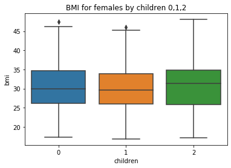

```python
sns.boxplot(x = "children", y = "bmi", data = female_bmi_by_children)
plt.title('BMI for females by children 0,1,2')
plt.show()
```

### Step 1: State the null and alternative hypothesis:

- $H_0$: $\mu1$ = $\mu2$ = $\mu3$
- $H_A$: At least one $\mu$ differs

### Step 2: Decide the significance level

Here we select α = 0.05

### Step 4: Calculate p value using ANOVA table

- statsmodels.formula.api.ols creates a model from a formula and dataframe
- statsmodels.api.sm.stats.anova_lm gives an Anova table for one or more fitted linear models

```python
import statsmodels.api         as     sm
from   statsmodels.formula.api import ols

mod = ols('bmi ~ children', data = female_bmi_by_children).fit()
aov_table = sm.stats.anova_lm(mod, typ=2)
print(aov_table)
```

```
                sum_sq     df         F   PR(>F)
children      2.512982    1.0  0.068411  0.79376
Residual  20717.738725  564.0       NaN      NaN
```

In this example, p value is 0.79376 and it is greater than our chosen level of signifance at 5%

So the statistical decision is to not reject the null hypothesis at 5% level of significance.